# Multidimensional Models

## Estimation of multidimensional models

### With polycor package and factanal() function

*lavaan* itself isn’t very supportive in performing CEFA (and EFA). There are packages that help to overcome this problem with *lavaan* ([semTools](https://github.com/simsem/semTools/wiki)), but we will turn to a more classical solution: estimating a matrix of polychoric correlations with package *polycor* and using base R `factanal()` function.

```r
library(polycor)
# computing ML estimates is very time consuming!
# change ML argument to FALSE or read a pre-computed matrix with load() (below)
# corImportant = hetcor(important[, 3:23], use = "pairwise.complete.obs",
#                       ML = TRUE, std.err = FALSE)
load("corImportant.RData")
corImportant
```

```
##
## Maximum-Likelihood Estimates
##
## Correlations/Type of Correlation:
##         ipcrtiv    imprich    ipeqopt    ipshabt    impsafe    impdiff
## ipcrtiv       1 Polychoric Polychoric Polychoric Polychoric Polychoric
## imprich    0.25          1 Polychoric Polychoric Polychoric Polychoric
## ipeqopt  0.1868   -0.03655          1 Polychoric Polychoric Polychoric
## ipshabt  0.3918     0.3653     0.2028          1 Polychoric Polychoric
## impsafe 0.07529    0.01164     0.4566     0.2132          1 Polychoric
## impdiff  0.4247     0.1998      0.213     0.3591      0.104          1
## ipfrule 0.07337   -0.05742     0.3396     0.1519     0.3654     0.1404
## ipudrst  0.2462    -0.1009      0.388     0.1732     0.2639     0.3086
## ipmodst -0.0497    -0.2554     0.2836   -0.02032     0.3203   -0.02183
## ipgdtim  0.2638     0.3605    0.08253     0.2896   -0.02337     0.3652
## impfree  0.3584     0.1185     0.2787     0.2914     0.2058     0.3491
## iphlppl  0.1962    -0.1416     0.3898     0.1727     0.2446     0.2659
## ipsuces  0.3666     0.3678      0.125     0.5455     0.0956     0.3763
## ipstrgv  0.1415     0.0183     0.4067     0.1885     0.4832     0.1506
## ipadvnt  0.3541     0.3371   0.005819     0.3197    -0.2043     0.4276
## ipbhprp  0.0427   -0.03671     0.3094     0.1416     0.4393    0.07767
## iprspot    0.12     0.2921     0.1495     0.2995     0.2994    0.09459
## iplylfr  0.2393   -0.02366     0.4335     0.2337     0.4042     0.2784
## impenv   0.1713   -0.08155       0.42     0.1465     0.3707     0.2317
## imptrad -0.0237    -0.1291     0.2757    0.06157     0.3754    0.04204
## impfun   0.2225     0.3041     0.1142      0.286    -0.0296     0.3145
##            ipfrule    ipudrst    ipmodst    ipgdtim    impfree    iphlppl
## ipcrtiv Polychoric Polychoric Polychoric Polychoric Polychoric Polychoric
## imprich Polychoric Polychoric Polychoric Polychoric Polychoric Polychoric
## ipeqopt Polychoric Polychoric Polychoric Polychoric Polychoric Polychoric
## ipshabt Polychoric Polychoric Polychoric Polychoric Polychoric Polychoric
## impsafe Polychoric Polychoric Polychoric Polychoric Polychoric Polychoric
## impdiff Polychoric Polychoric Polychoric Polychoric Polychoric Polychoric
## ipfrule          1 Polychoric Polychoric Polychoric Polychoric Polychoric
## ipudrst     0.3154          1 Polychoric Polychoric Polychoric Polychoric
## ipmodst     0.3602     0.2874          1 Polychoric Polychoric Polychoric
## ipgdtim   -0.07278    0.08206   -0.09771          1 Polychoric Polychoric
## impfree     0.1231      0.346    0.01056      0.293          1 Polychoric
## iphlppl     0.2613     0.4397     0.2776     0.1172     0.3537          1
## ipsuces      0.125     0.2289    -0.0735      0.372     0.3456     0.2146
```

[output cut: 37 more lines]

```
## ipfrule Polychoric Polychoric Polychoric
## ipudrst Polychoric Polychoric Polychoric
## ipmodst Polychoric Polychoric Polychoric
## ipgdtim Polychoric Polychoric Polychoric
## impfree Polychoric Polychoric Polychoric
## iphlppl Polychoric Polychoric Polychoric
## ipsuces Polychoric Polychoric Polychoric
## ipstrgv Polychoric Polychoric Polychoric
## ipadvnt Polychoric Polychoric Polychoric
## ipbhprp Polychoric Polychoric Polychoric
## iprspot Polychoric Polychoric Polychoric
## iplylfr Polychoric Polychoric Polychoric
## impenv           1 Polychoric Polychoric
## imptrad     0.4384          1 Polychoric
## impfun     0.07044   -0.09779          1
```

```r
# estimating models
mf = lapply(1:7,
            function(x, cm, n) {
              return(factanal(factors = x, covmat = cm, n.obs = n))},
            cm = corImportant$correlations, n = nrow(important))
# argument cutoff of the print() function allows not to show
# factor loadings that are to small to be of our interest
lapply(mf, print, cutoff = 0.3)
```

```
##
## Call:
## factanal(factors = x, covmat = cm, n.obs = n)
##
## Uniquenesses:
## ipcrtiv imprich ipeqopt ipshabt impsafe impdiff ipfrule ipudrst ipmodst
##   0.890   0.999   0.626   0.855   0.666   0.844   0.755   0.671   0.862
## ipgdtim impfree iphlppl ipsuces ipstrgv ipadvnt ipbhprp iprspot iplylfr
##   0.957   0.742   0.616   0.862   0.591   0.989   0.668   0.871   0.493
##  impenv imptrad  impfun
##   0.557   0.736   0.957
##
## Loadings:
##         Factor1
## ipcrtiv 0.332
## imprich
## ipeqopt 0.611
## ipshabt 0.381
## impsafe 0.578
## impdiff 0.395
## ipfrule 0.495
## ipudrst 0.573
## ipmodst 0.371
## ipgdtim
## impfree 0.508
## iphlppl 0.620
## ipsuces 0.371
## ipstrgv 0.639
## ipadvnt
## ipbhprp 0.576
## iprspot 0.360
## iplylfr 0.712
## impenv  0.666
## imptrad 0.514
## impfun
##
##                Factor1
## SS loadings      4.792
## Proportion Var   0.228
##
```

[output cut: 252 more lines]

```
## ipbhprp  0.611
## iprspot                                  0.567
## iplylfr                  0.823           0.312
## impenv   0.472           0.503
## imptrad  0.712
## impfun                           0.796
##
##                Factor1 Factor2 Factor3 Factor4 Factor5 Factor6 Factor7
## SS loadings      2.489   2.328   2.053   1.934   0.844   0.841   0.707
## Proportion Var   0.119   0.111   0.098   0.092   0.040   0.040   0.034
## Cumulative Var   0.119   0.229   0.327   0.419   0.459   0.499   0.533
##
## Test of the hypothesis that 7 factors are sufficient.
## The chi square statistic is 339.11 on 84 degrees of freedom.
## The p-value is 2.29e-32
```

```
## [[1]]
##
## Call:
## factanal(factors = x, covmat = cm, n.obs = n)
##
## Uniquenesses:
## ipcrtiv imprich ipeqopt ipshabt impsafe impdiff ipfrule ipudrst ipmodst
##   0.890   0.999   0.626   0.855   0.666   0.844   0.755   0.671   0.862
## ipgdtim impfree iphlppl ipsuces ipstrgv ipadvnt ipbhprp iprspot iplylfr
##   0.957   0.742   0.616   0.862   0.591   0.989   0.668   0.871   0.493
##  impenv imptrad  impfun
##   0.557   0.736   0.957
##
## Loadings:
##         Factor1
## ipcrtiv 0.332
## imprich
## ipeqopt 0.611
## ipshabt 0.381
## impsafe 0.578
## impdiff 0.395
## ipfrule 0.495
## ipudrst 0.573
## ipmodst 0.371
## ipgdtim 0.206
## impfree 0.508
## iphlppl 0.620
## ipsuces 0.371
## ipstrgv 0.639
## ipadvnt 0.105
## ipbhprp 0.576
## iprspot 0.360
## iplylfr 0.712
## impenv  0.666
## imptrad 0.514
## impfun  0.208
##
##                Factor1
## SS loadings      4.792
## Proportion Var   0.228
```

[output cut: 265 more lines]

```
## ipbhprp  0.611           0.186           0.224   0.113   0.229
## iprspot  0.267   0.167           0.111   0.567
## iplylfr  0.214   0.125   0.823           0.312   0.134
## impenv   0.472   0.107   0.503                   0.132
## imptrad  0.712           0.191
## impfun           0.215           0.796
##
##                Factor1 Factor2 Factor3 Factor4 Factor5 Factor6 Factor7
## SS loadings      2.489   2.328   2.053   1.934   0.844   0.841   0.707
## Proportion Var   0.119   0.111   0.098   0.092   0.040   0.040   0.034
## Cumulative Var   0.119   0.229   0.327   0.419   0.459   0.499   0.533
##
## Test of the hypothesis that 7 factors are sufficient.
## The chi square statistic is 339.11 on 84 degrees of freedom.
## The p-value is 2.29e-32
```

Let’s note that:

- Once we compute a matrix of polychoric correlations (what can take a long time), estimating CEFA models with `factanal()` is done very quickly, irrespective of number of factors (however it wasn’t so easy in `70s or`80s of the 20th century).
- Information about *cummulative variance* on the last factor can be used to determine, what is a reasonable number of factors.
  - This is quite-similar to determining a proper number of clusters in a cluster analysis (especially when non-hierarchical method is used, like k-means).
- In principle we could also use chi-squared test to compare (stepwise) models with different number of factors. However:
  - With more than 200-500 cases it often leads to choosing a model with more factors, than we can reasonably interpret.
  - Test reported at the end of `print()` method’s output tests a model against a saturated model and thus typically isn’t helpful.
  - There is no `anova()` method defined for objects of class *factanal*, so there is no convinient way to perform such a test.

Below there is a graph showing mean *uniqueness* as a function of number of factors.

- In a continous variables factor analysis *uniqueness* is simply a part of variance of an observed variable, that is not shared with latent factors (ie. 1-*communality*). In a CEFA/CCFA case it’s quite the same, however it’s not about observed (ordered categorical) variable’s variance, but about variance of its continous (and unobservable) *latent response* counterpart (see slide 13. of “Intorduction.pdf”).

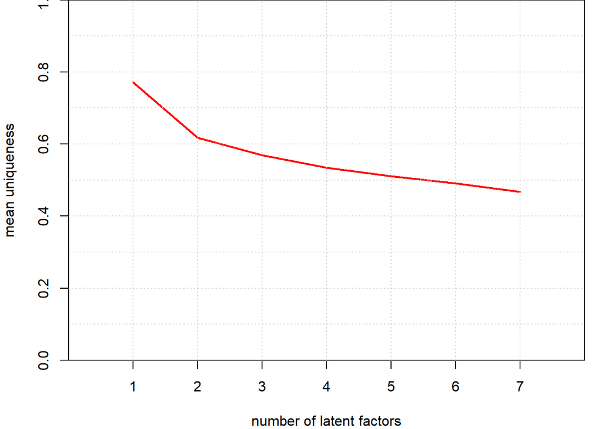

```r
par(mar = c(4, 4, 0, 1))
meanUniqueness = sapply(mf, function(x) {return(mean(x$uniquenesses))})
nf = sapply(mf, function(x) {return(x$factors)})
plot(nf, meanUniqueness, type = "l", lwd = 2, col = 2, ylim = c(0, 1), yaxs = "i",
     xlim = c(0, max(nf) + 1), xaxp = c(1, max(nf), max(nf) - 1), xaxs = "i",
     xlab = "number of latent factors", ylab = "mean uniqueness")
grid(nx = max(nf) + 1, ny = 10)
```

Using *elbow rule* we may conclude, that we should choose model with only 2 factors.

Let’s take a look at this model:

```r
temp = mf[[2]]$loadings
rownames(temp) = essVarLabels$label[3:23]
print(temp, cutoff = 0.3)
```

```
##
## Loadings:
##                                                                        Factor1
## Important to think new ideas and being creative
## Important to be rich, have money and expensive things
## Important that people are treated equally and have equal opportunities  0.593
## Important to show abilities and be admired
## Important to live in secure and safe surroundings                       0.640
## Important to try new and different things in life
## Important to do what is told and follow rules                           0.565
## Important to understand different people                                0.533
## Important to be humble and modest, not draw attention                   0.488
## Important to have a good time
## Important to make own decisions and be free                             0.366
## Important to help people and care for others well-being                 0.575
## Important to be successful and that people recognize achievements
## Important that government is strong and ensures safety                  0.642
## Important to seek adventures and have an exciting life
## Important to behave properly                                            0.648
## Important to get respect from others                                    0.304
## Important to be loyal to friends and devote to people close             0.641
## Important to care for nature and environment                            0.659
## Important to follow traditions and customs                              0.628
## Important to seek fun and things that give pleasure
##                                                                        Factor2
## Important to think new ideas and being creative                         0.496
## Important to be rich, have money and expensive things                   0.467
## Important that people are treated equally and have equal opportunities
## Important to show abilities and be admired                              0.521
## Important to live in secure and safe surroundings
## Important to try new and different things in life                       0.560
## Important to do what is told and follow rules
## Important to understand different people
## Important to be humble and modest, not draw attention
## Important to have a good time                                           0.715
## Important to make own decisions and be free                             0.449
## Important to help people and care for others well-being
## Important to be successful and that people recognize achievements       0.634
## Important that government is strong and ensures safety
## Important to seek adventures and have an exciting life                  0.783
## Important to behave properly
## Important to get respect from others
## Important to be loyal to friends and devote to people close
## Important to care for nature and environment
## Important to follow traditions and customs
## Important to seek fun and things that give pleasure                     0.708
##
##                Factor1 Factor2
## SS loadings      4.434   3.600
## Proportion Var   0.211   0.171
## Cumulative Var   0.211   0.383
```

By default `factanal()` assumes that latent factors are orthogonal (ie. independent of each other). We can see, that questions divides very well between two factors - that’s very nice. Only `impfree` is *cross-loaded* having considerably big factor lodings with more than one factor.

### With mirt

We can easily estimate exploratory models with *mirt* package. However there will appear some problem when number of latent factors rises, because within IRT approach to estimation computational complexity rises exponentially as a function of number of latent variables.

```r
library(mirt)
importantNumeric = as.data.frame(lapply(important[, 3:23], as.numeric))
mm1 = mirt(importantNumeric, 1)
```

[output not shown]

[output cut: 76 more lines]

[output not shown]

```r
# decreasing default convergence threshold to speed up computations
mm2 = mirt(importantNumeric, 2, TOL = 0.001)
```

[output not shown]

[output cut: 24 more lines]

[output not shown]

```r
# this would take a long time, so better give it up
# mm3 = mirt(importantNumeric, 3, TOL = 0.001)

# in summary() method for mirt objects argument 'suppress' has a similar role to
# 'cutoff' argument in print() method for factanal objects
summary(mm2, suppress = 0.3, rotate = "none")
```

```
##
## Unrotated factor loadings:
##
##             F1     F2    h2
## ipcrtiv -0.500     NA 0.297
## imprich -0.507     NA 0.272
## ipeqopt     NA -0.637 0.417
## ipshabt -0.531     NA 0.353
## impsafe     NA -0.669 0.450
## impdiff -0.551     NA 0.377
## ipfrule     NA -0.599 0.369
## ipudrst     NA -0.594 0.374
## ipmodst     NA -0.504 0.306
## ipgdtim -0.753     NA 0.567
## impfree -0.424 -0.428 0.364
## iphlppl     NA -0.635 0.430
## ipsuces -0.653     NA 0.474
## ipstrgv     NA -0.693 0.486
## ipadvnt -0.811     NA 0.677
## ipbhprp     NA -0.683 0.471
## iprspot     NA -0.338 0.157
## iplylfr     NA -0.700 0.549
## impenv      NA -0.713 0.517
## imptrad     NA -0.650 0.455
## impfun  -0.742     NA 0.550
##
## SS loadings:  NA NA
## Proportion Var:  NA NA
##
## Factor correlations:
##
##    F1 F2
## F1  1  0
## F2  0  1
```

## Factor rotations

It may be unintuitive, but for a given multidimensional factor model there is infinite number of (combinations of values in) factor loadings matrices that provides equally good model fit (this is connected with choosing a basis of a vector space). Statistical methods that enables to obtain such matrices that have some desirable properties are called rotations. Typically it is expected to obtain factor loadings matrix providing good *separation* of factors, ie. that for each factor there are either strong loadings or loadings with values close to 0 and there are no cross-loaded items. Two perhaps most videly used rotations of this type are *varimax* and *oblimin*.

- *Varimax* provides a solution in which latent factor orthogonality is assumed.
- *Oblimin* allows latnt factors to be correlated (if this can help to obtain better *separtion* of factor loadings).
  - `summary()` method for *mirt* models uses *oblimin* rotation by default to compute presented factor loadings matrix.

There are many different rotations (see `?GPArotation::rotations`), for example bi-factor roatations, trying to provide solutions with one *common* factor and additional separated from each other *specific* factors.

Let’s look on rotated solutions of our 2-dimensional model:

```r
library(GPArotation)
mf2dNone = mf[[2]]$loadings
(mf2dVarimax = Varimax(mf2dNone, normalize = TRUE))
```

```
## Orthogonal rotation method varimax converged.
## Loadings:
##         Factor1 Factor2
## ipcrtiv  0.1622  0.4965
## imprich -0.1378  0.4669
## ipeqopt  0.5926  0.1487
## ipshabt  0.2181  0.5207
## impsafe  0.6395 -0.0222
## impdiff  0.2107  0.5596
## ipfrule  0.5645 -0.0458
## ipudrst  0.5328  0.1909
## ipmodst  0.4876 -0.1883
## ipgdtim -0.0457  0.7148
## impfree  0.3662  0.4486
## iphlppl  0.5747  0.2054
## ipsuces  0.1645  0.6343
## ipstrgv  0.6421  0.1250
## ipadvnt -0.1886  0.7830
## ipbhprp  0.6481 -0.0268
## iprspot  0.3040  0.2308
## iplylfr  0.6414  0.2799
## impenv   0.6592  0.1262
## imptrad  0.6279 -0.1423
## impfun  -0.0424  0.7080
##
## Rotating matrix:
##          [,1]    [,2]
## [1,]  1.0e+00 4.7e-05
## [2,] -4.7e-05 1.0e+00
```

```r
(mf2dOblimin = oblimin(mf2dNone))
```

```
## Oblique rotation method Oblimin Quartimin converged.
## Loadings:
##         Factor1 Factor2
## ipcrtiv  0.1760  0.4742
## imprich -0.1262  0.4831
## ipeqopt  0.5994  0.0722
## ipshabt  0.2328  0.4911
## impsafe  0.6420 -0.1041
## impdiff  0.2264  0.5309
## ipfrule  0.5661 -0.1181
## ipudrst  0.5404  0.1220
## ipmodst  0.4850 -0.2503
## ipgdtim -0.0272  0.7185
## impfree  0.3798  0.4002
## iphlppl  0.5829  0.1310
## ipsuces  0.1819  0.6113
## ipstrgv  0.6485  0.0423
## ipadvnt -0.1690  0.8049
## ipbhprp  0.6505 -0.1098
## iprspot  0.3115  0.1911
## iplylfr  0.6519  0.1968
## impenv   0.6657  0.0412
## imptrad  0.6273 -0.2224
## impfun  -0.0240  0.7113
##
## Rotating matrix:
##        [,1]   [,2]
## [1,] 1.0049 -0.128
## [2,] 0.0262  0.997
##
## Phi:
##       [,1]  [,2]
## [1,] 1.000 0.102
## [2,] 0.102 1.000
```

```r
# let's put it all together
solutions = data.frame(variable = essVarLabels$label[3:23],
                       cbind(mf2dNone, mf2dVarimax$loadings, mf2dOblimin$loadings))
names(solutions)[-1] = c("unrot. F1", "unrot. F2", "varimax F1", "varimax F2",
                         "oblimin F1", "oblimin F2")
solutions[-1] = lapply(solutions[-1],
                       function(x, cutoff) {
                         return(ifelse(abs(x) < cutoff,
                                       "",
                                       format(round(x, 2), nsmall = 2)))},
                       cutoff = 0.3)
solutions
```

```
##                                                                       variable
## ipcrtiv                        Important to think new ideas and being creative
## imprich                  Important to be rich, have money and expensive things
## ipeqopt Important that people are treated equally and have equal opportunities
## ipshabt                             Important to show abilities and be admired
## impsafe                      Important to live in secure and safe surroundings
## impdiff                      Important to try new and different things in life
## ipfrule                          Important to do what is told and follow rules
## ipudrst                               Important to understand different people
## ipmodst                  Important to be humble and modest, not draw attention
## ipgdtim                                          Important to have a good time
## impfree                            Important to make own decisions and be free
## iphlppl                Important to help people and care for others well-being
## ipsuces      Important to be successful and that people recognize achievements
## ipstrgv                 Important that government is strong and ensures safety
## ipadvnt                 Important to seek adventures and have an exciting life
## ipbhprp                                           Important to behave properly
## iprspot                                   Important to get respect from others
## iplylfr            Important to be loyal to friends and devote to people close
## impenv                            Important to care for nature and environment
## imptrad                             Important to follow traditions and customs
## impfun                     Important to seek fun and things that give pleasure
##         unrot. F1 unrot. F2 varimax F1 varimax F2 oblimin F1 oblimin F2
## ipcrtiv                0.50                  0.50                  0.47
## imprich                0.47                  0.47                  0.48
## ipeqopt      0.59                 0.59                  0.60
## ipshabt                0.52                  0.52                  0.49
## impsafe      0.64                 0.64                  0.64
## impdiff                0.56                  0.56                  0.53
## ipfrule      0.56                 0.56                  0.57
## ipudrst      0.53                 0.53                  0.54
## ipmodst      0.49                 0.49                  0.49
## ipgdtim                0.71                  0.71                  0.72
## impfree      0.37      0.45       0.37       0.45       0.38       0.40
## iphlppl      0.57                 0.57                  0.58
## ipsuces                0.63                  0.63                  0.61
## ipstrgv      0.64                 0.64                  0.65
## ipadvnt                0.78                  0.78                  0.80
## ipbhprp      0.65                 0.65                  0.65
## iprspot      0.30                 0.30                  0.31
## iplylfr      0.64                 0.64                  0.65
## impenv       0.66                 0.66                  0.67
## imptrad      0.63                 0.63                  0.63
## impfun                 0.71                  0.71                  0.71
```

In our case rotations hardly changes a solution (but it is not always the case).

With *mirt* objects we can see rotated factor scores matrix using `summary()` method. We can also extract unrotated solution with `extract.mirt()` function and rotate it ourself.

```r
summary(mm2, rotate = "varimax", normalize = TRUE)
```

```
##
## Rotation:  varimax
##
## Rotated factor loadings:
##
##               F1      F2    h2
## ipcrtiv -0.51257 -0.1853 0.297
## imprich -0.49856  0.1543 0.272
## ipeqopt -0.14645 -0.6291 0.417
## ipshabt -0.54724 -0.2311 0.353
## impsafe  0.00834 -0.6705 0.450
## impdiff -0.56747 -0.2335 0.377
## ipfrule  0.06141 -0.6047 0.369
## ipudrst -0.18457 -0.5829 0.374
## ipmodst  0.19497 -0.5173 0.306
## ipgdtim -0.75172  0.0453 0.567
## impfree -0.45121 -0.4001 0.364
## iphlppl -0.20318 -0.6237 0.430
## ipsuces -0.66583 -0.1756 0.474
## ipstrgv -0.12559 -0.6859 0.486
## ipadvnt -0.80099  0.1870 0.677
## ipbhprp  0.02277 -0.6861 0.471
## iprspot -0.22969 -0.3235 0.157
## iplylfr -0.28552 -0.6834 0.549
## impenv  -0.13438 -0.7061 0.517
## imptrad  0.13736 -0.6604 0.455
## impfun  -0.74020  0.0479 0.550
##
## Rotated SS loadings:  3.86 5.051
##
## Factor correlations:
##
##    F1 F2
## F1  1  0
## F2  0  1
```

```r
Varimax(extract.mirt(mm2, "F"), normalize = TRUE)
```

```
## Orthogonal rotation method varimax converged.
## Loadings:
##               F1      F2
## ipcrtiv -0.51257 -0.1853
## imprich -0.49856  0.1543
## ipeqopt -0.14645 -0.6291
## ipshabt -0.54724 -0.2311
## impsafe  0.00834 -0.6705
## impdiff -0.56747 -0.2335
## ipfrule  0.06141 -0.6047
## ipudrst -0.18457 -0.5829
## ipmodst  0.19497 -0.5173
## ipgdtim -0.75172  0.0453
## impfree -0.45121 -0.4001
## iphlppl -0.20318 -0.6237
## ipsuces -0.66583 -0.1756
## ipstrgv -0.12559 -0.6859
## ipadvnt -0.80099  0.1870
## ipbhprp  0.02277 -0.6861
## iprspot -0.22969 -0.3235
## iplylfr -0.28552 -0.6834
## impenv  -0.13438 -0.7061
## imptrad  0.13736 -0.6604
## impfun  -0.74020  0.0479
##
## Rotating matrix:
##        [,1]    [,2]
## [1,] 0.9979 -0.0645
## [2,] 0.0645  0.9979
```

# Confirmatory multidimensional models

Having determined the structure of our set of questions with exploratory analysis we can construct confirmatory models. Because each of the questions except *impfree* may be assigned to only one of the two latent factors, and factor loadings of *impfree* are similar on both factors, it seems that the best solution will be to exclude *impfree* from analysis.

Multidimensional confirmative models can be described to `mirt()` with pseudo-formula notation. Code below assigns questions to factors (excluding *impfree*) and allows nonorthogonality of latent factors. Questions are identified not by its names, but as a position in a dataframe provided by the `data` argument.

```r
modelMirt = '
F1 = 3, 5, 7-9, 12, 14, 16-20
F2 = 1-2, 4, 6, 10, 13, 15, 21
COV = F1*F2'
mm2c = mirt(importantNumeric, modelMirt)
```

[output not shown]

[output cut: 142 more lines]

[output not shown]

```r
summary(mm2c)
```

```
##            F1    F2    h2
## ipcrtiv 0.000 0.495 0.245
## imprich 0.000 0.506 0.256
## ipeqopt 0.644 0.000 0.415
## ipshabt 0.000 0.555 0.309
## impsafe 0.662 0.000 0.438
## impdiff 0.000 0.566 0.320
## ipfrule 0.585 0.000 0.343
## ipudrst 0.585 0.000 0.342
## ipmodst 0.491 0.000 0.241
## ipgdtim 0.000 0.762 0.580
## impfree 0.000 0.000 0.000
## iphlppl 0.631 0.000 0.399
## ipsuces 0.000 0.665 0.442
## ipstrgv 0.697 0.000 0.485
## ipadvnt 0.000 0.780 0.608
## ipbhprp 0.687 0.000 0.472
## iprspot 0.361 0.000 0.130
## iplylfr 0.707 0.000 0.500
## impenv  0.721 0.000 0.519
## imptrad 0.644 0.000 0.415
## impfun  0.000 0.746 0.557
##
## SS loadings:  4.699 3.316
## Proportion Var:  0.224 0.158
##
## Factor correlations:
##
##       F1    F2
## F1 1.000 0.129
## F2 0.129 1.000
```

In *lavaan* we can do the same with:

```r
library(lavaan)
important[3:23] = lapply(important[3:23], ordered)
modelLavaan = '
F1 =~ ipeqopt + impsafe + ipfrule + ipudrst + ipmodst + iphlppl + ipstrgv +
      ipbhprp + iprspot + iplylfr + impenv + imptrad
F2 =~ ipcrtiv + imprich + ipshabt + impdiff + ipgdtim + ipsuces + ipadvnt + impfun
F1 ~~ F2'
mf2c = cfa(modelLavaan, important)
summary(mf2c, fit.measures = TRUE, standardized = TRUE)
```

```
## lavaan (0.6-1) converged normally after  30 iterations
##
##                                                   Used       Total
##   Number of observations                          1541        1685
##
##   Estimator                                       DWLS      Robust
##   Model Fit Test Statistic                    4078.305    3671.604
##   Degrees of freedom                               169         169
##   P-value (Chi-square)                           0.000       0.000
##   Scaling correction factor                                  1.129
##   Shift parameter                                           59.828
##     for simple second-order correction (Mplus variant)
##
## Model test baseline model:
##
##   Minimum Function Test Statistic            34570.240   17328.609
##   Degrees of freedom                               190         190
##   P-value                                        0.000       0.000
##
## User model versus baseline model:
##
##   Comparative Fit Index (CFI)                    0.886       0.796
##   Tucker-Lewis Index (TLI)                       0.872       0.770
##
##   Robust Comparative Fit Index (CFI)                            NA
##   Robust Tucker-Lewis Index (TLI)                               NA
##
## Root Mean Square Error of Approximation:
##
##   RMSEA                                          0.123       0.116
##   90 Percent Confidence Interval          0.119  0.126       0.113  0.119
##   P-value RMSEA <= 0.05                          0.000       0.000
##
##   Robust RMSEA                                                  NA
##   90 Percent Confidence Interval                                NA     NA
##
## Standardized Root Mean Square Residual:
##
##   SRMR                                           0.103       0.103
##
```

[output cut: 195 more lines]

```
##     iphlppl           1.000                               1.000    1.000
##     ipstrgv           1.000                               1.000    1.000
##     ipbhprp           1.000                               1.000    1.000
##     iprspot           1.000                               1.000    1.000
##     iplylfr           1.000                               1.000    1.000
##     impenv            1.000                               1.000    1.000
##     imptrad           1.000                               1.000    1.000
##     ipcrtiv           1.000                               1.000    1.000
##     imprich           1.000                               1.000    1.000
##     ipshabt           1.000                               1.000    1.000
##     impdiff           1.000                               1.000    1.000
##     ipgdtim           1.000                               1.000    1.000
##     ipsuces           1.000                               1.000    1.000
##     ipadvnt           1.000                               1.000    1.000
##     impfun            1.000                               1.000    1.000
```

We can see that this model doesn’t fit data very well. Probably adding some cross loadings could help.

# Factor scores from multidimensional models

If we estimate a multidimensional model corelations between latent factors are this model’s parameters (even if they’re sometimes fixed to be 0 - if we assume orthogonality). Do this correlations hold between factor scores extracted from a model?

```r
modelMirtOrtho = '
F1 = 3, 5, 7-9, 12, 14, 16-20
F2 = 1-2, 4, 6, 10, 13, 15, 21'
mm2co = mirt(importantNumeric, modelMirtOrtho)
```

[output not shown]

[output cut: 10 more lines]

[output not shown]

```r
rF1F2 = round(coef(mm2c)$GroupPars[4], 2)

fs = data.frame(fscores(mm2c),
                fscores(mm2co))
names(fs) = c("F1", "F2", "F1 ortho.", "F2 ortho.")
round(cor(fs), 2)
```

```
##             F1   F2 F1 ortho. F2 ortho.
## F1        1.00 0.15      1.00      0.12
## F2        0.15 1.00      0.13      1.00
## F1 ortho. 1.00 0.13      1.00      0.10
## F2 ortho. 0.12 1.00      0.10      1.00
```

```r
# here we can find value of a parameter of the mm2c model describing latent correlation
round(coef(mm2c)$GroupPars, 2)
```

```
##     MEAN_1 MEAN_2 COV_11 COV_21 COV_22
## par      0      0      1   0.13      1
```

```r
# what happens if we make a test?
cor.test(fs$`F1 ortho.`, fs$`F2 ortho.`)
```

```
##
##  Pearson's product-moment correlation
##
## data:  fs$`F1 ortho.` and fs$`F2 ortho.`
## t = 4.1843, df = 1683, p-value = 3.009e-05
## alternative hypothesis: true correlation is not equal to 0
## 95 percent confidence interval:
##  0.05397615 0.14850193
## sample estimates:
##      cor
## 0.101468
```

We can see, that **factor scores estimated on the basis of an orthogonal model aren’t orthogonal**. Correlation between them is rather weak, but if we perform hypothesis testing and have quite large dataset, it will often turn out to be significantly different from 0.

Although in our case correlation between factor scores estimated on the basis of non orthogonal model appeared to be very close to a latent correlation, typically this can’t be taken for granted. **Especially with models with strong latent correlation (not our case), there will be clear tendency that a correlation between factor scores be much stronger, than a latent correlation.** Because of that with regards to multidimensional models it should be always well thought, whether it is better to provide factor scores estimated on the basis of such a model, or rather on the basis of few separate one-dimesional models.